# Preprocessing MSI data using MALDIquant

Paolo Inglese

15/10/2021

## About

First load the required packages:

```r
library(MALDIquant)
library(MALDIquantForeign)
library(irlba)
library(viridis)
```

## Importing ImzML

For this tutorial, I will use a MALDI-MSI dataset `EY_210930pm_EDI-27jul21_p56-Male-642-12-6-T_50um_2SE` collected from a mouse brain in positive ion mode.  
The dataset is publicly available on [METASPACE2020](https://metaspace2020.eu/) (*thanks to Eylan Yutuc for sharing it online*).

```r
peaks <- importImzMl('EY_210930pm_EDI-27jul21_p56-Male-642-12-6-T_50um_2SE.imzML', centroided = TRUE, verbose = FALSE)
```

Some details about the dataset

```r
# Total number of pixels
print(length(peaks))
```

```
## [1] 35000
```

```r
# Spatial dimensions (same metadata for all pixels)
print(peaks[[1]]@metaData$imaging$size)
```

```
##   x   y
## 250 140
```

Let’s have a look at the distribution of the number of detected peaks and pixels mean intensities (in the log-space):

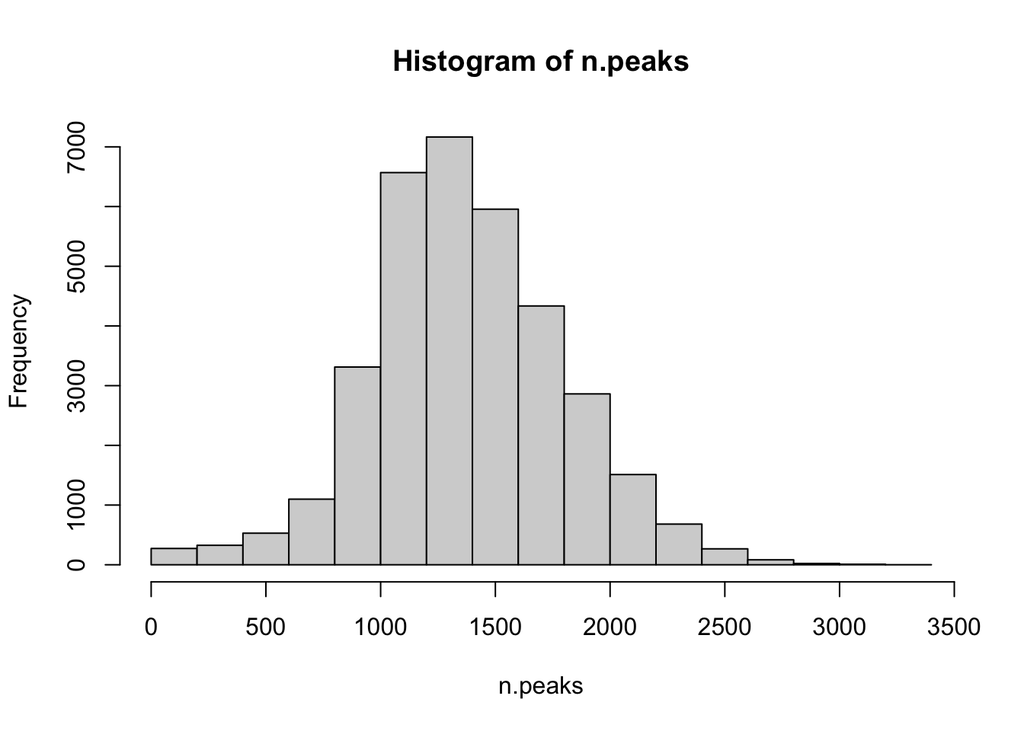

```r
n.peaks <- unlist(lapply(peaks, function(x) length(mass(x))))

hist(n.peaks)
```

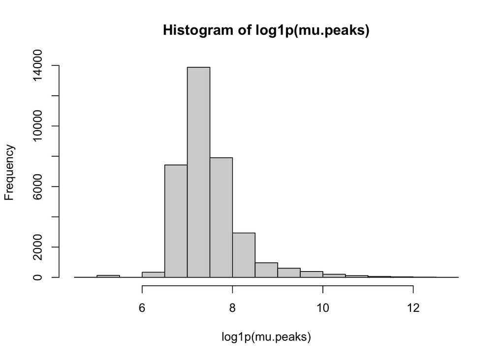

```r
mu.peaks <- unlist(lapply(peaks, function(x) mean(intensity(x))))

hist(log1p(mu.peaks))
```

We can check that we have a set of MS peaks (class `MassPeaks`):

```r
print(class(peaks[[1]]))
```

```
## [1] "MassPeaks"
## attr(,"package")
## [1] "MALDIquant"
```

and plot the peaks from one pixel:

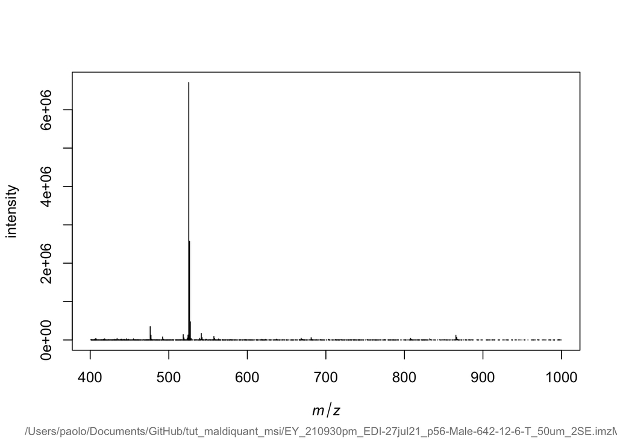

```r
plot(peaks[[3000]])
```

# Total-ion-count (TIC) image

A quick way to check the spatial properties of an MSI dataset is to plot the TIC image. In this image, each pixel represents its total peaks intensity:

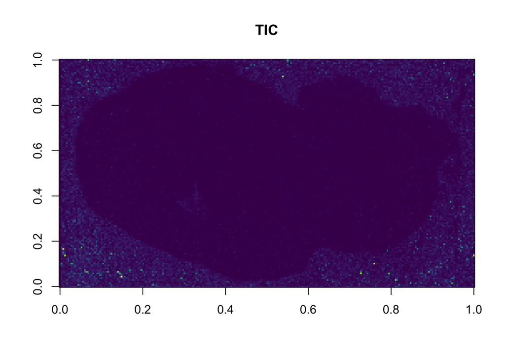

```r
tic <- unlist(lapply(peaks, function(x) sum(intensity(x))))
tic <- matrix(tic, peaks[[1]]@metaData$imaging$size)
image(tic, col=viridis(64))
title('TIC')
```

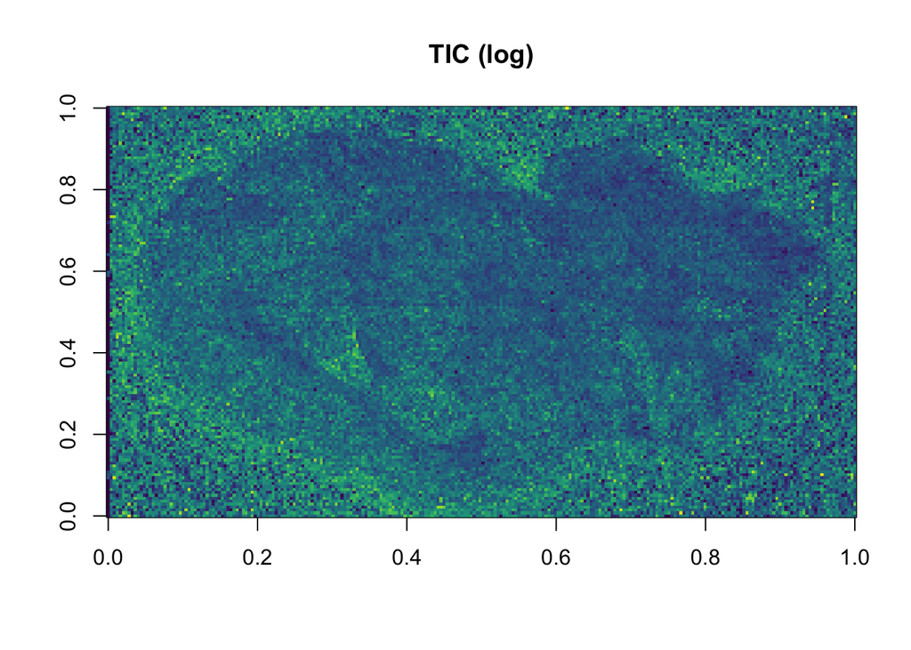

```r
tic.log <- unlist(lapply(peaks, function(x) sum(log1p(intensity(x)))))
tic.log <- matrix(tic.log, peaks[[1]]@metaData$imaging$size)
image(tic.log, col=viridis(64))
title('TIC (log)')
```

## Peak binning (or peak matching)

After quick checking some details of the dataset, we can start processing it. The first step is matching the peaks across all pixels. In this way, we assign the peaks intensities to a set of common masses, based on the similarity of their original values.  
This can be done by calling the function `binPeaks` from `MALDIquant`. We save the new masses in the same list of `MassPeaks` (NOTE: this procedure will overwrite the original masses, so if you want to keep them, you have to export the results in a different list).

We will use the ‘strict’ method, and a tolerance of 20 ppm:

```r
# binPeaks tolerance is expressed in delta mass / mass, we want it in ppm:
tol.ppm <- 20
tol.maldiquant <- tol.ppm / 1e6

# The new common masses will overwrite the original ones. The intensities remain unmodified
peaks <- binPeaks(peaks, method = 'strict', tolerance = tol.maldiquant)
```

### Intensity matrix (feature)

To perform downstream analysis we need the so-called intensity matrix (or feature matrix), representing the intensities of all peaks assigned to the common masses. This matrix has a shape *npixels* x *nfeatures* and it’s generated using the function `intensityMatrix` from `MALDIquant`.

*NOTE*: depending on the dataset, this matrix can be very big, so large amount of RAM may be necessary

```r
# This can occupy a lot of RAM
X <- intensityMatrix(peaks)
```

*NOTE*: `MALDIquant` sets the unassigned values to `NA`. You may need to convert them to 0 for downstream analysis.

In this case, we have a whooping number of common masses equal to:

```r
# most of the common masses represent noise!
ncol(X)
```

```
## [1] 181591
```

Most of these features are noise, as we can see from their assignment frequency:

```r
# Unfortunately my computer doesn't have enough RAM to run apply
nz <- array(0, ncol(X))
for (i in 1:ncol(X)) nz[i] <- sum(!is.na(X[, i]))
```

```r
summary(nz / nrow(X))
```

```
##      Min.   1st Qu.    Median      Mean   3rd Qu.      Max.
## 0.0000286 0.0001429 0.0003714 0.0075767 0.0014857 0.9943143
```

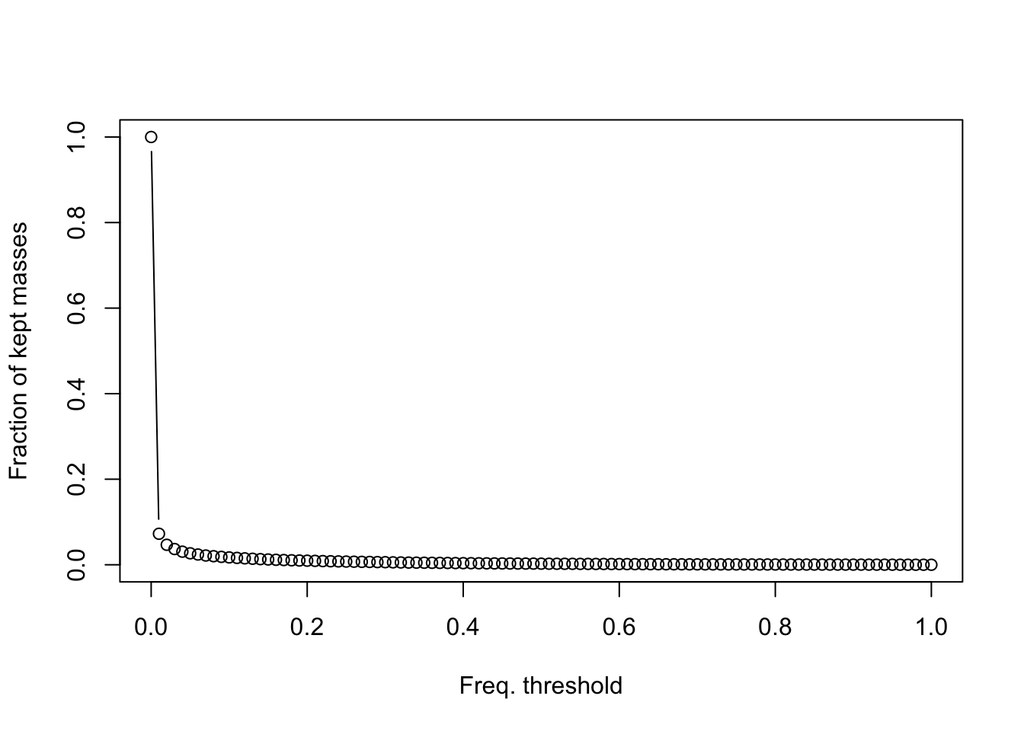

```r
plot(seq(0, 1, 0.01), sapply(seq(0, 1, 0.01), function(x) sum(nz / nrow(X) > x) / length(nz)),
     xlab = 'Freq. threshold',
     ylab = 'Fraction of kept masses', type = 'b')
```

As we can see, less than 10% of the common masses are detected in more than 1% of the pixels.

We can set 5% as a threshold to remove the *rare* features (this is quite arbitrary and now based on memory constraints)

```r
keep.mass <- which(nz > nrow(X) * 0.05)
X <- X[, keep.mass]

dim(X)
```

```
## [1] 35000  4871
```

We now have 4,871 features which looks more reasonable than > 100,000.

*NOTE*: let’s covert the `NA` to 0.

```r
X[is.na(X)] <- 0
```

## Normalization and log-transformation

We can now normalize the intensities to take into account of the pixel-to-pixel variations.  
To do so, we use TIC scaling. Also we apply a log-transformation to reduce the skeweness of the intensity distributions.

```r
scaling.factor <- apply(X, 1, sum)
X <- X / scaling.factor

# Be sure that the empty pixels are set to 0
X[scaling.factor == 0, ] <- 0

X <- log1p(X)
```

## How the data looks like?

A quick way to check the global molecular heterogeneity of the sample is based on plotting the first 3 principal components (PC) as RGB channels. We use [`irlba`](https://cran.r-project.org/package=irlba) to quickly extract the first 3 PC:

```r
results <- irlba::prcomp_irlba(X, center = TRUE, scale. = TRUE, n = 3)
```

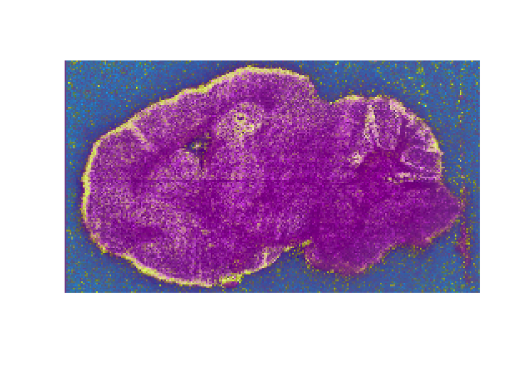

```r
# First rescale the scores in [0, 1]
pc <- apply(results$x, 2, function(x) (x - min(x)) / (max(x) - min(x)))

# Create the RGB
im <- rgb(pc[, 1], pc[, 2], pc[, 3])

im <- matrix(im, peaks[[1]]@metaData$imaging$size)
# Plot the image as a raster (transpose before)
plot(as.raster(t(im)), interpolate = FALSE)
```

The image shows some degree of heterogeneity of the tissue, and its difference from the off-tissue region.

## Ready for downstream analysis

Now that we have the preprocessed intensity matrix, we can perform downstream analysis, such as supervised classification, clustering, etc.

In this tutorial, we have used a basic filtering approach to reduce the number of common masses. More sophisticated methods based on the spatial information are available, such as [`SPUTNIK`](https://cran.r-project.org/package=SPUTNIK) (Inglese et al. 2018)

Gibb, Sebastian, and Korbinian Strimmer. 2012. “MALDIquant: A Versatile R Package for the Analysis of Mass Spectrometry Data.” *Bioinformatics* 28 (17): 2270–71. https://doi.org/10.1093/bioinformatics/bts447.

Inglese, Paolo, Gonçalo Correia, Zoltan Takats, Jeremy K Nicholson, and Robert C Glen. 2018. “SPUTNIK: an R package for filtering of spatially related peaks in mass spectrometry imaging data.” *Bioinformatics* 35 (1): 178–80. https://doi.org/10.1093/bioinformatics/bty622.